# Order Recommendation System for Instacart

#### **Instacart Overview**

##### **I ndustry Background**

Online grocery shopping is changing the whole supermarket industry. Same-day grocery delivery industry is on trend and is predicted to worth $18 billion value by the end of 2018. Niche online grocery services are competing over conventional grocery business with its advantages such as convenience and selection. According to an online survey, 25% of millennials said they would pay a premium for same-day delivery. Grocery giants such as Amazon, Costco and Target are offering same-day grocery delivery service.

##### **What is Instacart?**

Instacart is an American company that operates as a same-day grocery on-demand delivery service and has its headquarter at San Francisco. Instacart’s service is mainly provided through online order by an app and Instacart personal shoppers simply go to a store and purchase the ordered items at a chosen retail. As of March 2017, Instacart services 36 markets, composed of 1,200 cities in 25 states including California, Arizona and New York. In the same month it was valued at approximately $3.4 billion dollars and was considered “one of the most valuable companies in the America.”

##### **I nstacart’s Business Model**

Instacart Customers are given a decision to shop from any store that is situated nearby. Personal shoppers who are found nearby the store will receive the order and starts collecting items as mentioned in the order. Shoppers are paid hourly rate while customers are also allowed to tip the shoppers. Shoppers pays the bill through Instacart’s prepaid debit card which is accepted at the store. The shopper then goes to deliver the groceries to the customer.

##### **I nstacart’s Revenue Model**

Delivery charges: Delivery charges are Instacart’s fundamental profits. The charges may be higher if the customer requires speedier delivery or in busier circumstances. There are two options: Order above $35 entices a fixed delivery charge of $3.99 to $5.99; orders less than $35 are priced $7.99 to $9.99.

• Membership fee: Instacart also extends an annual membership scheme priced at $99 and is termed “Instacart Express”. Users can opt for the membership to get groceries delivered at no cost for the entire one year. • Mark-up charges: Products sold through the Instacart platform, some are priced as the same as store while in some cases priced 15% higher than the retail price. The revenue generated through these mark-up fees goes to the Instacart wallet. • First Free Delivery: Instacart hypnotizes customers with a free delivery options for users who chooses to use the Instacart facility app for the first time, so pretty much a smart way to solve the “cold start” problem and provide more incentive for new app users to place an order.

##### **Dataset**

The dataset published by Instacart itself, called “The Instacart Online Grocery Shopping Dataset 2017”, is a relational set of files describing customers’ orders over time. The dataset is anonymized and contains a sample of over 3 million grocery orders from more than 200,000 Instacart users. For each user, between 4 and 100 of their orders are provided, with the sequence of products purchased in each order.

The “order_products_” tables contains two sub-tables, which are order_products_prior table and order_products_train table. They are the most essential tables we are using for our analysis. They specify which products were purchased in each order and the add-to-cart order of each product purchased. They also contain a binary attribute ‘reordered’, with 1 indicates the customer has a previous order that contains the product. These tables can be connected with products table via product_id and with orders table via order_id.

The “orders” table, which contains 3,421,083 purchasing records, tells to which evaluation set (prior, train, test) an order belongs. Plus the day and time an order was placed, which may help us determine when is the best time to send the recommendation. It is another essential table for our analysis.

##### **Questions**

Customer satisfaction is a major influence factor of customer retention rate. Most of Instacart users are busy people who do not have time going to grocery store on their own. By predicting which products an user will buy again and recommend these products to users during their shopping process, Instacart may offer better convenience to its users. Therefore, customer buying activities and satisfaction rate are both likely to increase, which not only drives to a higher revenue, but also more loyal customers.

In this project, the core question is: Can we increase active customers and customer buying activities by improving the order recommendation system based on their previous orders? To know when and what should we recommend to each customer, we need to glean some insights on customers’ order placing behaviors. Therefore, we can break down the core question into the following sub-questions:

1. When should we send our recommendation?
2. How many items should our recommendation contain?
3. What products should we recommend?
4. Bonus: output your prediction on test dataset and show which kind of products would mostly reordered.

*prior- purchase order in the past* train- the very last purchase *order_number: how many times this customer buy the product

##### **Load Data**

```r
rm(list = ls())
library(dplyr)
```

```r
library(ggplot2)
library(gridExtra)
aisles <- read.csv("dataset/aisles.csv")
departments <- read.csv("dataset/departments.csv")
order_products__prior <- read.csv("dataset/order_products__prior.csv")
order_products__train <- read.csv("dataset/order_products__train.csv")
orders <- read.csv("dataset/orders.csv")
products <- read.csv("dataset/products.csv")
```

##### **aisles**

```r
head(aisles)
```

|  | aisle_id | aisle |
| --- | --- | --- |
| 1 | 1 | prepared soups salads |
| 2 | 2 | specialty cheeses |
| 3 | 3 | energy granola bars |
| 4 | 4 | instant foods |
| 5 | 5 | marinades meat preparation |
| 6 | 6 | other |

```r
str(aisles)
```

```
## 'data.frame':    134 obs. of  2 variables:
##  $ aisle_id: int  1 2 3 4 5 6 7 8 9 10 ...
##  $ aisle   : chr  "prepared soups salads" "specialty cheeses" "energy granola bars" "instant foods" ...
```

```r
summary(aisles)
```

```
##     aisle_id         aisle
##  Min.   :  1.00   Length:134
##  1st Qu.: 34.25   Class :character
##  Median : 67.50   Mode  :character
##  Mean   : 67.50
##  3rd Qu.:100.75
##  Max.   :134.00
```

##### **Observation: 134 types of aisles**

##### **departments**

```r
head(departments)
```

|  | department_id | department |
| --- | --- | --- |
| 1 | 1 | frozen |
| 2 | 2 | other |
| 3 | 3 | bakery |
| 4 | 4 | produce |
| 5 | 5 | alcohol |
| 6 | 6 | international |

```r
str(departments)
```

```
## 'data.frame':    21 obs. of  2 variables:
##  $ department_id: int  1 2 3 4 5 6 7 8 9 10 ...
##  $ department   : chr  "frozen" "other" "bakery" "produce" ...
```

```r
summary(departments)
```

```
##  department_id  department
##  Min.   : 1    Length:21
##  1st Qu.: 6    Class :character
##  Median :11    Mode  :character
##  Mean   :11
##  3rd Qu.:16
##  Max.   :21
```

##### **Observation: 21 department**

##### **products**

```r
head(products)
```

|  | product_id | product_name | aisle_id | department_id |
| --- | --- | --- | --- | --- |
| 1 | 1 | Chocolate Sandwich Cookies | 61 | 19 |
| 2 | 2 | All-Seasons Salt | 104 | 13 |
| 3 | 3 | Robust Golden Unsweetened Oolong Tea | 94 | 7 |
| 4 | 4 | Smart Ones Classic Favorites Mini Rigatoni With Vodka Cream Sauce | 38 | 1 |
| 5 | 5 | Green Chile Anytime Sauce | 5 | 13 |
| 6 | 6 | Dry Nose Oil | 11 | 11 |

```r
str(products)
```

```
## 'data.frame':    49688 obs. of  4 variables:
##  $ product_id   : int  1 2 3 4 5 6 7 8 9 10 ...
##  $ product_name : chr  "Chocolate Sandwich Cookies" "All-Seasons Salt" "Robust Golden Unsweetened Oolong Tea" "Smart Ones Classic Favorites Mini Rigatoni With Vodka Cream Sauce" ...
##  $ aisle_id     : int  61 104 94 38 5 11 98 116 120 115 ...
##  $ department_id: int  19 13 7 1 13 11 7 1 16 7 ...
```

```r
summary(products)
```

```
##    product_id    product_name          aisle_id      department_id
##  Min.   :    1   Length:49688       Min.   :  1.00   Min.   : 1.00
##  1st Qu.:12423   Class :character   1st Qu.: 35.00   1st Qu.: 7.00
##  Median :24845   Mode  :character   Median : 69.00   Median :13.00
##  Mean   :24845                      Mean   : 67.77   Mean   :11.73
##  3rd Qu.:37266                      3rd Qu.:100.00   3rd Qu.:17.00
##  Max.   :49688                      Max.   :134.00   Max.   :21.00
```

##### **Observation: 49688 products**

##### **order_products__prior**

```r
head(order_products__train)
```

|  | order_id | product_id | add_to_cart_order | reordered |
| --- | --- | --- | --- | --- |
| 1 | 1 | 49302 | 1 | 1 |
| 2 | 1 | 11109 | 2 | 1 |
| 3 | 1 | 10246 | 3 | 0 |
| 4 | 1 | 49683 | 4 | 0 |
| 5 | 1 | 43633 | 5 | 1 |
| 6 | 1 | 13176 | 6 | 0 |

```r
str(order_products__prior)
```

```
## 'data.frame':    32434489 obs. of  4 variables:
##  $ order_id         : int  2 2 2 2 2 2 2 2 2 3 ...
##  $ product_id       : int  33120 28985 9327 45918 30035 17794 40141 1819 43668 33754 ...
##  $ add_to_cart_order: int  1 2 3 4 5 6 7 8 9 1 ...
##  $ reordered        : int  1 1 0 1 0 1 1 1 0 1 ...
```

```r
summary(order_products__train)
```

```
##     order_id         product_id    add_to_cart_order   reordered
##  Min.   :      1   Min.   :    1   Min.   : 1.000    Min.   :0.0000
##  1st Qu.: 843370   1st Qu.:13380   1st Qu.: 3.000    1st Qu.:0.0000
##  Median :1701880   Median :25298   Median : 7.000    Median :1.0000
##  Mean   :1706298   Mean   :25556   Mean   : 8.758    Mean   :0.5986
##  3rd Qu.:2568023   3rd Qu.:37940   3rd Qu.:12.000    3rd Qu.:1.0000
##  Max.   :3421070   Max.   :49688   Max.   :80.000    Max.   :1.0000
```

##### **orders**

```r
head(orders)
```

|  | order_id | user_id | eval_set | order_number | order_dow | order_hour_of_day | days_since_prior_order |
| --- | --- | --- | --- | --- | --- | --- | --- |
| 1 | 2539329 | 1 | prior | 1 | 2 | 8 | NA |
| 2 | 2398795 | 1 | prior | 2 | 3 | 7 | 15 |
| 3 | 473747 | 1 | prior | 3 | 3 | 12 | 21 |
| 4 | 2254736 | 1 | prior | 4 | 4 | 7 | 29 |
| 5 | 431534 | 1 | prior | 5 | 4 | 15 | 28 |
| 6 | 3367565 | 1 | prior | 6 | 2 | 7 | 19 |

```r
str(orders)
```

```
## 'data.frame':    3421083 obs. of  7 variables:
##  $ order_id              : int  2539329 2398795 473747 2254736 431534 3367565 550135 3108588 2295261 2550362 ...
##  $ user_id               : int  1 1 1 1 1 1 1 1 1 1 ...
##  $ eval_set              : chr  "prior" "prior" "prior" "prior" ...
##  $ order_number          : int  1 2 3 4 5 6 7 8 9 10 ...
##  $ order_dow             : int  2 3 3 4 4 2 1 1 1 4 ...
##  $ order_hour_of_day     : int  8 7 12 7 15 7 9 14 16 8 ...
##  $ days_since_prior_order: num  NA 15 21 29 28 19 20 14 0 30 ...
```

```r
summary(orders)
```

```
##     order_id          user_id         eval_set          order_number
##  Min.   :      1   Min.   :     1   Length:3421083     Min.   :  1.00
##  1st Qu.: 855272   1st Qu.: 51394   Class :character   1st Qu.:  5.00
##  Median :1710542   Median :102689   Mode  :character   Median : 11.00
##  Mean   :1710542   Mean   :102978                      Mean   : 17.15
##  3rd Qu.:2565812   3rd Qu.:154385                      3rd Qu.: 23.00
##  Max.   :3421083   Max.   :206209                      Max.   :100.00
##
##    order_dow     order_hour_of_day days_since_prior_order
##  Min.   :0.000   Min.   : 0.00     Min.   : 0.00
##  1st Qu.:1.000   1st Qu.:10.00     1st Qu.: 4.00
##  Median :3.000   Median :13.00     Median : 7.00
##  Mean   :2.776   Mean   :13.45     Mean   :11.11
##  3rd Qu.:5.000   3rd Qu.:16.00     3rd Qu.:15.00
##  Max.   :6.000   Max.   :23.00     Max.   :30.00
##                                    NA's   :206209
```

### Exploratory Data Analysis (EDA)

#####1) when do customer order

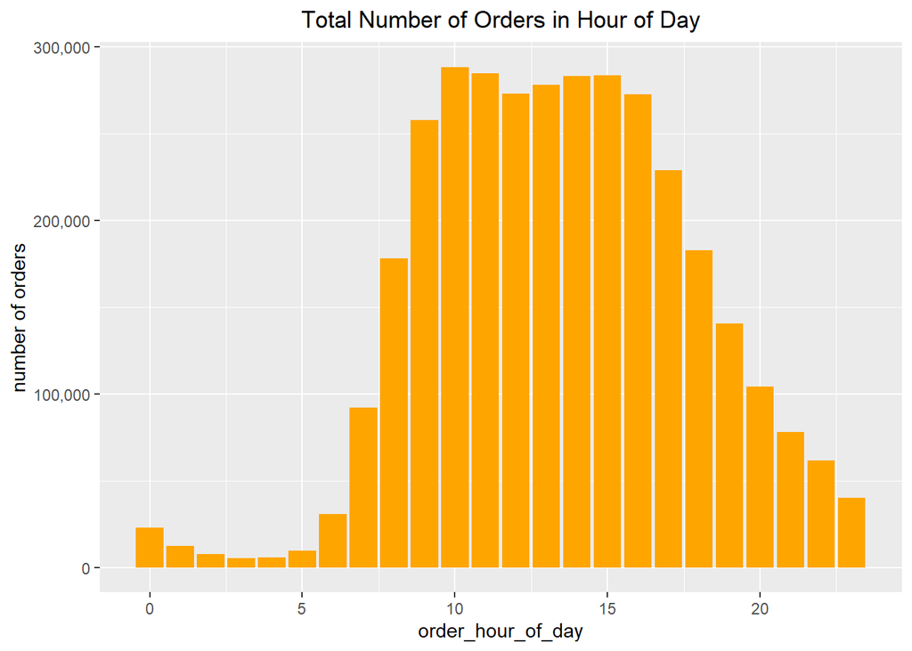

```r
#str(orders)
# orders and hours distribution

p1<-orders%>% ggplot(aes(x = order_hour_of_day)) + geom_bar(stat = 'count',fill = "orange") + ylab('number of orders')+
  scale_y_continuous(labels = scales::comma)+ggtitle('Total Number of Orders in Hour of Day') +
  theme(plot.title = element_text(hjust = 0.5))
p1
```

####Observation:

**Most orders are from 8am to 18pm daily**

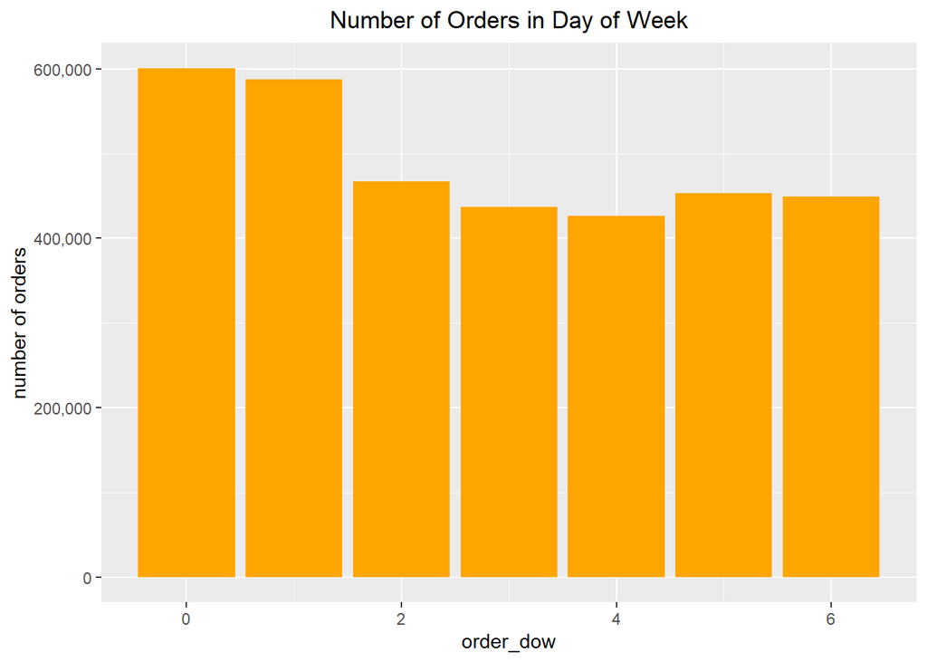

```r
#orders and weekdays distribution

p2 <- orders %>% ggplot(aes(x = order_dow)) +
  geom_bar(stat = "count", fill = "orange") + ylab('number of orders') +
  scale_y_continuous(labels = scales::comma) +
  ggtitle('Number of Orders in Day of Week') +
  theme(plot.title = element_text(hjust = 0.5))
p2
```

**Most order are amongst monday and Tuesday**

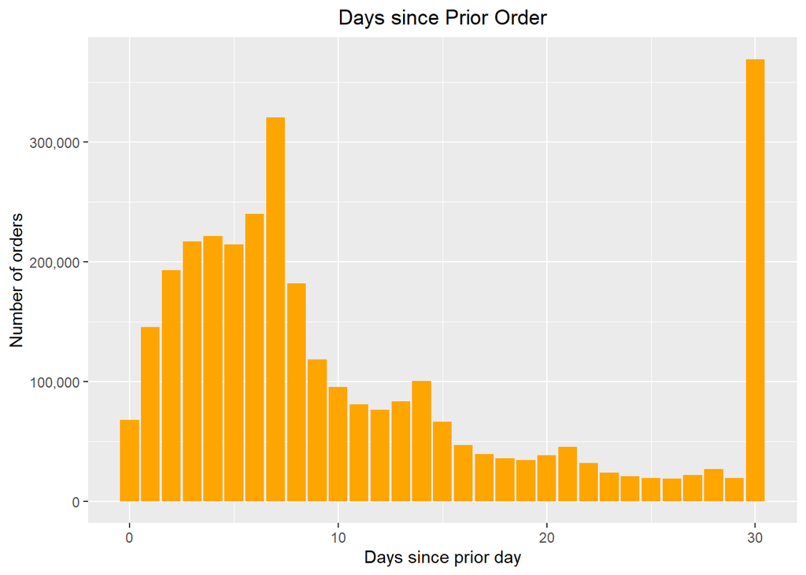

```r
# days since prior order

p3 <- orders %>% filter(days_since_prior_order != '')%>%
  ggplot(aes(x = days_since_prior_order))+
  geom_bar(stat = "count", fill = "orange") + ylab('Number of orders') +
  xlab('Days since prior day')+
  scale_y_continuous(labels = scales::comma) +
  ggtitle('Days since Prior Order') +
  theme(plot.title = element_text(hjust = 0.5))
p3
```

**Reorder frequency shows increase trend in first 7 days, then decreases, the highest frequency of re-order is once per month and then once per once per week**

##### Part 2: how many prior orders

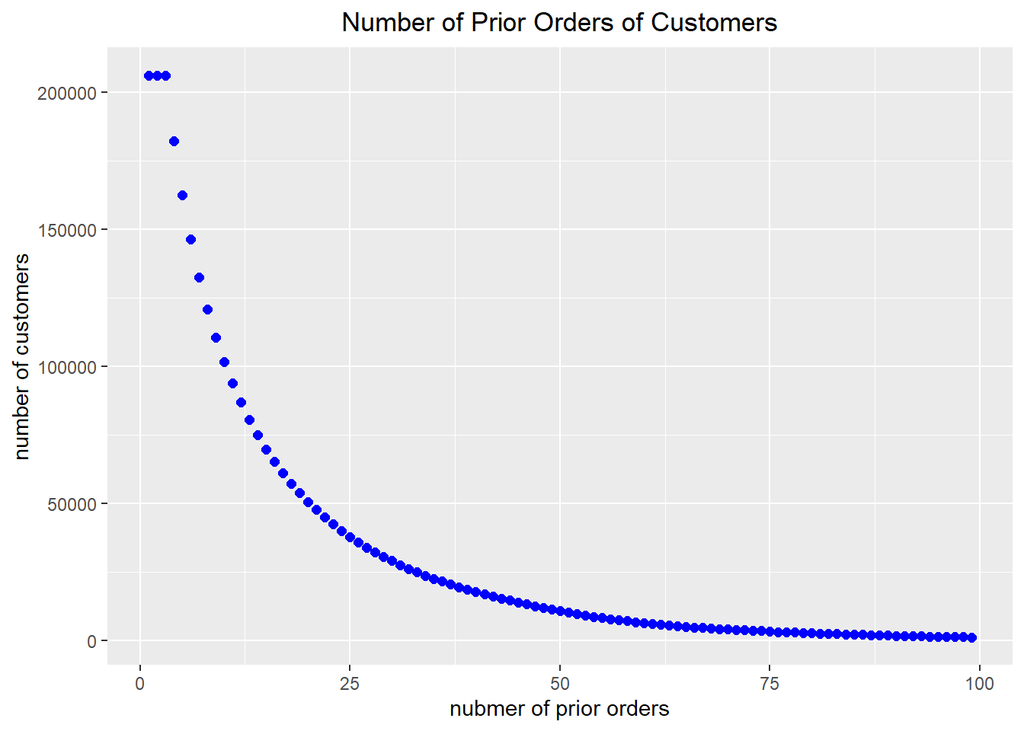

```r
p4 <- orders%>%filter(eval_set == 'prior') %>% count(order_number) %>%
  ggplot(aes(order_number,n)) + geom_point(color = "blue", size = 2) +
  ggtitle('Number of Prior Orders of Customers') +
  theme(plot.title = element_text(hjust = 0.5))+
  ylab('number of customers') + xlab('nubmer of prior orders')

p4
```

**the dataset include users that have 4~100 orders, we can see that there are at least 3 prior orders for each consumer** **the number of customer is decreasing as the order_number increase**

#####5 how many items each customer buy each time?

```r
summary(order_products__prior)
```

```
##     order_id         product_id    add_to_cart_order   reordered
##  Min.   :      2   Min.   :    1   Min.   :  1.000   Min.   :0.0000
##  1st Qu.: 855943   1st Qu.:13530   1st Qu.:  3.000   1st Qu.:0.0000
##  Median :1711048   Median :25256   Median :  6.000   Median :1.0000
##  Mean   :1710749   Mean   :25576   Mean   :  8.351   Mean   :0.5897
##  3rd Qu.:2565514   3rd Qu.:37935   3rd Qu.: 11.000   3rd Qu.:1.0000
##  Max.   :3421083   Max.   :49688   Max.   :145.000   Max.   :1.0000
```

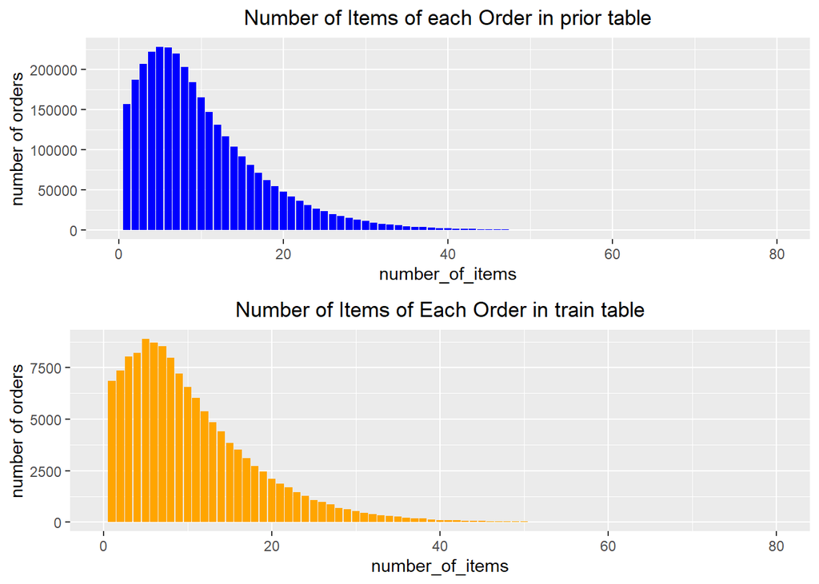

```r
##prior table

p51 <- order_products__prior %>% group_by(order_id) %>%
  summarise(number_of_items = last(add_to_cart_order)) %>%
  ggplot(aes(x = number_of_items)) + geom_bar(stat = 'count',fill='blue') + xlim(0,80) +
  ggtitle('Number of Items of each Order in prior table')+
  theme(plot.title = element_text(hjust = 0.5)) + ylab('number of orders')


## train table
p52 <- order_products__train %>% group_by(order_id) %>%
  summarise(number_of_items = last(add_to_cart_order)) %>%
  ggplot(aes(x = number_of_items)) +
  geom_histogram(stat = 'count', fill = 'orange') + xlim(0,80) +
  ggtitle('Number of Items of Each Order in train table') +
  theme(plot.title = element_text(hjust = 0.5)) + ylab('number of orders')
grid.arrange(p51,p52,nrow=2)
```

######How many of the items are reordered?

```r
df6<- order_products__prior%>%group_by(reordered)%>%
  summarise(count = n()) %>%
  mutate(proportion = round(count/sum(count),2))
df6
```

| reordered | count | proportion |
| --- | --- | --- |
| 0 | 13307953 | 0.41 |
| 1 | 19126536 | 0.59 |

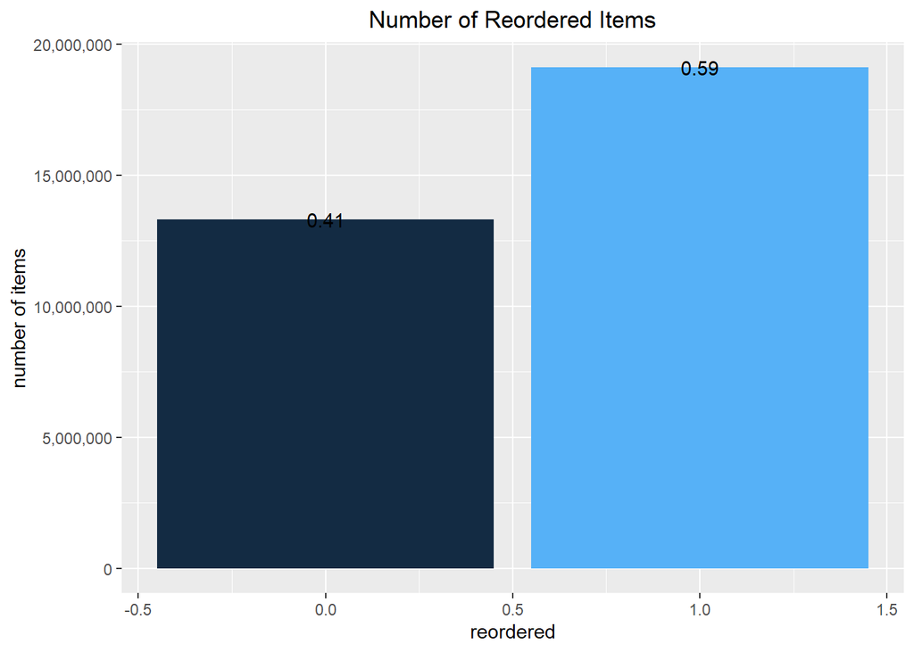

```r
p6<-df6%>%ggplot(aes(x=reordered,y = count,fill = reordered))+geom_bar(stat = 'identity')+ theme(legend.position = "none") +
  scale_y_continuous(labels = scales::comma) + ylab('number of items') +
  ggtitle('Number of Reordered Items') + # geom_col(aes(fill = reordered))
  theme(plot.title = element_text(hjust = 0.5)) +
  geom_text(aes(label = proportion))
p6
```

**59% of the items in prior table arfe re-ordered**

##Part 3: What are the popular products?

```r
#add to cart order : the order of the item placed in the cart
df7 <- order_products__prior %>% group_by(product_id)%>% summarise(proportion_reordered = mean(reordered),num_of_items = n())
df7
```

| product_id | proportion_reordered | num_of_items |
| --- | --- | --- |
| 1 | 0.61339093 | 1852 |
| 2 | 0.13333333 | 90 |
| 3 | 0.73285199 | 277 |
| 4 | 0.44680851 | 329 |
| 5 | 0.60000000 | 15 |
| 6 | 0.37500000 | 8 |
| 7 | 0.40000000 | 30 |
| 8 | 0.50303030 | 165 |
| 9 | 0.52564103 | 156 |
| 10 | 0.50699844 | 2572 |

[output cut: 9990 more lines]

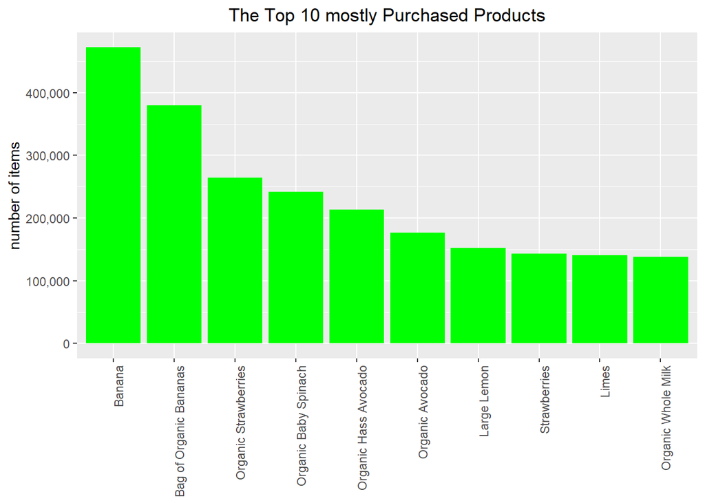

```r
df71 <- df7 %>% arrange(desc(num_of_items))%>% left_join(products, by = 'product_id')%>% head(10)

p7 <- df71 %>% ggplot(aes(x=reorder(product_name, -num_of_items), y=num_of_items))+
  geom_bar(stat = 'identity', fill = "green") + scale_y_continuous(labels = scales::comma) +ylab('number of items') + theme(axis.text.x = element_text(angle = 90,hjust = 1),axis.title.x = element_blank()) + ggtitle('The Top 10 mostly Purchased Products') +  theme(plot.title = element_text(hjust = 0.5))
p7
```

**Banana is the best seller**

##### what product in their first choice add to cart?

```r
df8<-order_products__train%>% group_by(product_id, add_to_cart_order) %>%
  summarise(count = n()) %>% mutate(pct = count/sum(count))
#df8

df81 <- df8 %>% filter(add_to_cart_order ==1, count>20) %>%left_join(products,by = 'product_id')%>%
  select(product_name,pct,count) %>% arrange(desc(pct))%>%head(10)
```

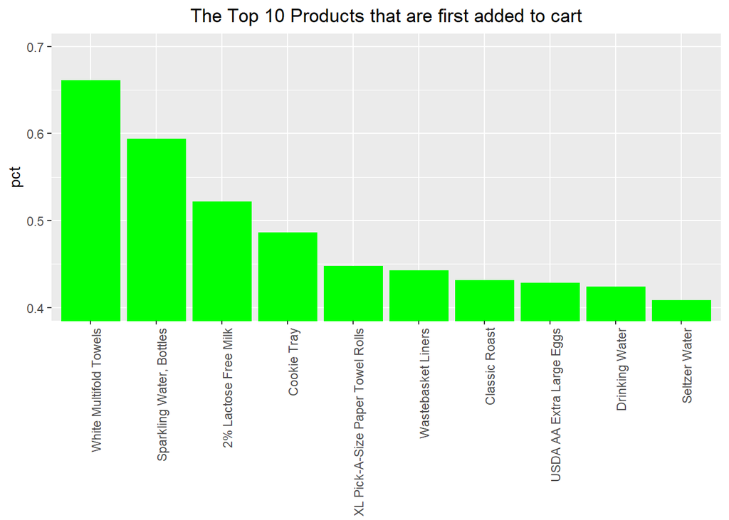

```r
#df81

p8 <- df81 %>% ggplot(aes(x=reorder(product_name,-pct), y=pct))+
  geom_bar(stat="identity",fill="green")+
  theme(axis.text.x=element_text(angle=90, hjust=1),axis.title.x = element_blank()) +
  coord_cartesian(ylim=c(0.4,0.7)) +
  ggtitle('The Top 10 Products that are first added to cart') +
  theme(plot.title = element_text(hjust = 0.5))
p8
```

**white multifold towels have the highest percentage add to cart**

##### Organic food vs non-organic food

```r
library(stringr)

df9<- products%>% mutate(organic = ifelse(str_detect(str_to_lower(products$product_name),'organic'),'organic','not organic'),organic = as.factor(organic))
head(df9)
```

|  | product_id | product_name | aisle_id | department_id | organic |
| --- | --- | --- | --- | --- | --- |
| 1 | 1 | Chocolate Sandwich Cookies | 61 | 19 | not organic |
| 2 | 2 | All-Seasons Salt | 104 | 13 | not organic |
| 3 | 3 | Robust Golden Unsweetened Oolong Tea | 94 | 7 | not organic |
| 4 | 4 | Smart Ones Classic Favorites Mini Rigatoni With Vodka Cream Sauce | 38 | 1 | not organic |
| 5 | 5 | Green Chile Anytime Sauce | 5 | 13 | not organic |
| 6 | 6 | Dry Nose Oil | 11 | 11 | not organic |

```r
prop.table(table(df9$organic))
```

```
##
## not organic     organic
##   0.8986476   0.1013524
```

**10% products are organic while 90% products are not organic**

#####how is the re-ordered percentage of organic and non-organic product

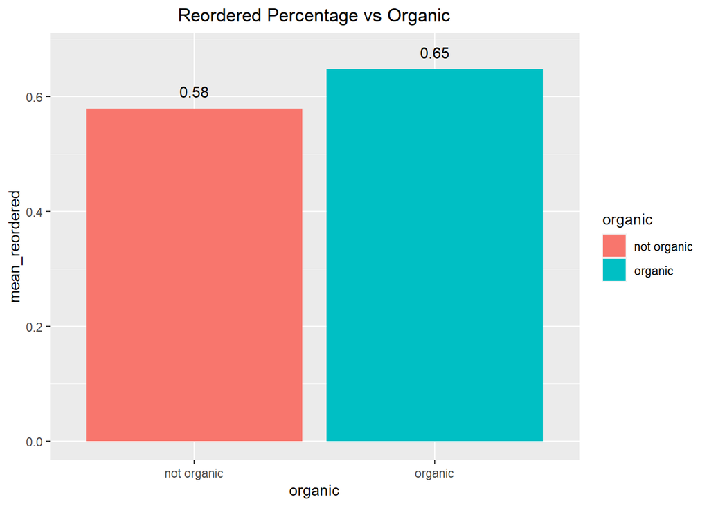

```r
df10 = order_products__train %>% left_join(df9, by = 'product_id') %>% group_by(organic) %>%
  summarise(mean_reordered = mean(reordered))
df10 %>% ggplot(aes(x= organic,y=mean_reordered, fill = organic)) +
  geom_bar(stat = 'identity') +
  geom_text(aes(label = round(mean_reordered, 2), y= mean_reordered + 0.03)) +
  ggtitle('Reordered Percentage vs Organic') +
  theme(plot.title = element_text(hjust = 0.5))
```

####organic product has 65 percentages reordered,although organic product only counts 10 percent as total but reorder rate of organic product is much higher than non-organic

#####Part 4: visualizing the product portfolio

#####How are aisles organized within departments?

```r
#install.packages('treemap')
library(treemap)
df11 <- products %>% group_by(department_id, aisle_id) %>% summarize(n=n()) %>%
  left_join(departments,by="department_id") %>%
  left_join(aisles,by="aisle_id")
df11
```

| department_id | aisle_id | n | department | aisle |
| --- | --- | --- | --- | --- |
| 1 | 34 | 229 | frozen | frozen meat seafood |
| 1 | 37 | 1091 | frozen | ice cream ice |
| 1 | 38 | 880 | frozen | frozen meals |
| 1 | 42 | 189 | frozen | frozen vegan vegetarian |
| 1 | 52 | 296 | frozen | frozen breakfast |
| 1 | 58 | 81 | frozen | frozen breads doughs |
| 1 | 79 | 335 | frozen | frozen pizza |
| 1 | 113 | 47 | frozen | frozen juice |
| 1 | 116 | 361 | frozen | frozen produce |
| 1 | 119 | 112 | frozen | frozen dessert |

[output cut: 124 more lines]

```r
map1 <- order_products__prior %>%
  group_by(product_id) %>%
  summarize(count=n()) %>%
  left_join(products,by="product_id") %>%
  ungroup() %>%
  group_by(department_id,aisle_id) %>%
  summarize(sumcount = sum(count)) %>%
  left_join(df11, by = c("department_id", "aisle_id")) %>%
  mutate(onesize = 1)
map1
```

| department_id | aisle_id | sumcount | n | department | aisle | onesize |
| --- | --- | --- | --- | --- | --- | --- |
| 1 | 34 | 71742 | 229 | frozen | frozen meat seafood | 1 |
| 1 | 37 | 498425 | 1091 | frozen | ice cream ice | 1 |
| 1 | 38 | 390299 | 880 | frozen | frozen meals | 1 |
| 1 | 42 | 99369 | 189 | frozen | frozen vegan vegetarian | 1 |
| 1 | 52 | 232763 | 296 | frozen | frozen breakfast | 1 |
| 1 | 58 | 40208 | 81 | frozen | frozen breads doughs | 1 |
| 1 | 79 | 162218 | 335 | frozen | frozen pizza | 1 |
| 1 | 113 | 4853 | 47 | frozen | frozen juice | 1 |
| 1 | 116 | 522654 | 361 | frozen | frozen produce | 1 |
| 1 | 119 | 19319 | 112 | frozen | frozen dessert | 1 |

[output cut: 124 more lines]

```r
# as we can see n means how many products in one deparment one aisle.
# sumcount means how many time the product has been ordered
```

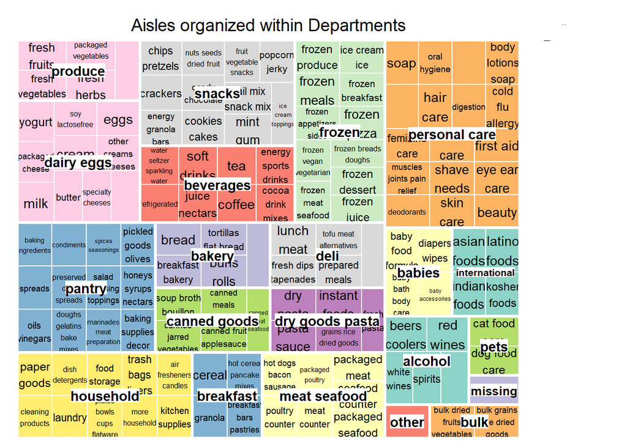

```r
treemap(map1,index=c("department","aisle"),
        vSize="onesize",vColor="department",
        palette="Set3",title="Aisles organized within Departments",
        sortID="-sumcount",
        border.col="#FFFFFF",type="categorical",
        fontsize.legend = 0,bg.labels = "#FFFFFF")
```

#####How many unique products are offered in each department/aisle?

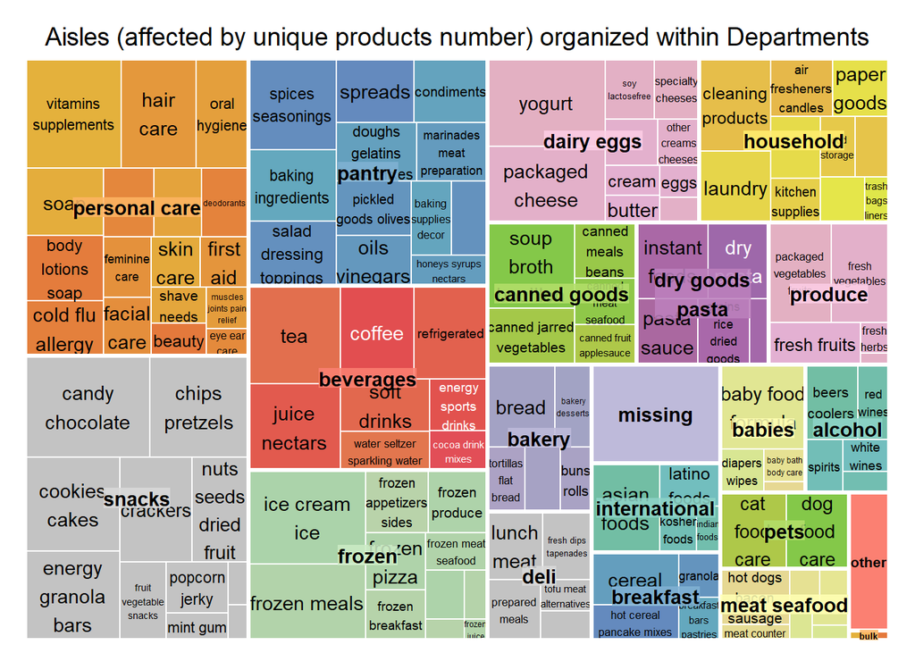

```r
treemap(df11,index=c("department","aisle"),
        vSize="n",title="Aisles (affected by unique products number) organized within Departments",
        palette="Set3",border.col="#FFFFFF")
```

#####How often are products from the department/aisle sold?

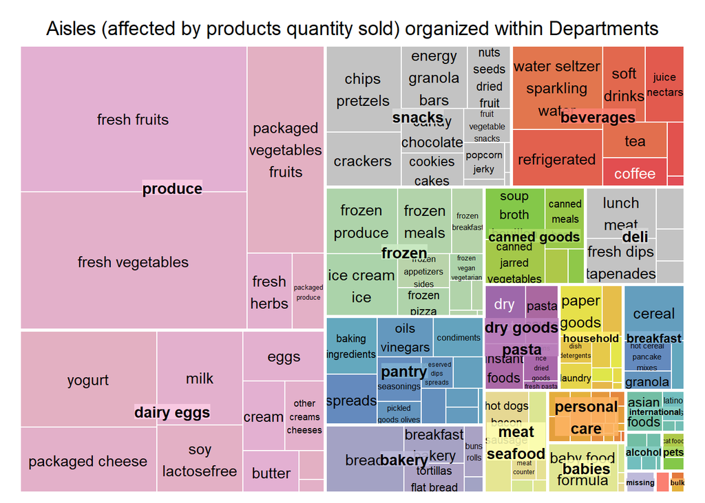

```r
treemap(map1,index=c("department","aisle"),
        vSize="sumcount",title="Aisles (affected by products quantity sold) organized within Departments",
        palette="Set3",border.col="#FFFFFF")
```

##### Main take-aways

1. When to recommend:
- Recommend at 7 days and 30 days after previous order.
- Recommend at 8:45 or 1:00 when users at break.
- Recommend when there are discounts in markets.
2. How many items to recommend:
- Mostly 4 to 7 items at a time, maximum 10.
- Divided into sublists for user-friendly viewing.
3. What to recommend:
- Popular products based on chosen aisles and departments of users.
- Related or potentially-interested aisles based on his ordered items.